# Example R Markdown Document

## What is Markdown?

Markdown is a syntax that lets us style our documents. Think of markdown as a simpler version of microsoft word with so many fewer clicks.

Here’s an overview of Markdown syntax that you can use anywhere on GitHub.com or in your own text files.

### Headers

```
# This is an h1 tag
## This is an h2 tag
###### This is an h6 tag
```

# This is an h1 tag

## This is an h2 tag

###### This is an h6 tag

### Emphasis

```
*This text will be italic*
_This will also be italic_

**This text will be bold**
__This will also be bold__

_You **can** combine them_
```

*This text will be italic* *This will also be italic*

**This text will be bold** **This will also be bold**

*You **can** combine them*

### Lists

#### Unordered

```
* Item 1
* Item 2
  * Item 2a
  * Item 2b
```

- Item 1
- Item 2
  - Item 2a
  - Item 2b

#### Ordered

```
1. Item 1
1. Item 2
1. Item 3
   1. Item 3a
   1. Item 3b
```

1. Item 1
2. Item 2
3. Item 3
   1. Item 3a
   2. Item 3b

### Images

```
![alt text](/image-path-or-url)
```

[figure not shown]

### Blockquotes

As Kanye West said:

```
> We're living the future so
> the present is our past.
```

> We’re living the future so the present is our past.

## R Markdown and code chunks

The powerhouse of R Markdown (Rmd) are **code chunks**. Code chunks start with `` ```{r} `` on its own line and end with `` ``` `` on it’s own line as well.

Create code chunks with the shortcut `cntrl` + `opt` + `i`.

Code chunks have lots of options. You can explore them with the little gear at the far right of the code chunk. We can choose to only show the output of the code and not the code itself by setting the chunk argument `echo = FALSE`.

```
## [1] "hello class!"
```

This is super helpful if you want to create a plot but not show anyone the code.

```
## Loading data for The Urban Informatics Toolkit.
```

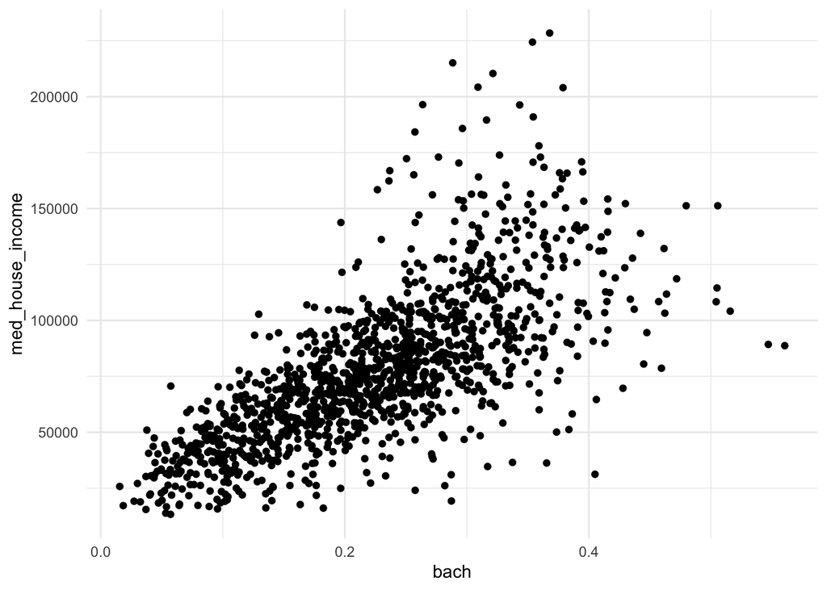

To change the type of document that you will create press the drop down next to the blue ball of yarn which says `Knit`. This will change the `output` to something like `pdf_document`.

The top section delineated with `---` is called the header. This is used to store metadata for the document such as the `title`, `author` (that’s you!), and the output type.

With R Markdown we can use cool packages like `kableExtra`, `reactable`, and `gt` to create pretty tables to look at!

```r
library(dplyr)

airbnb_hosts %>%
  group_by(since_year) %>%
  summarise(n_superhosts = sum(superhost, na.rm = TRUE),
            n_listings = sum(n_listings, na.rm = TRUE)) %>%
  arrange(-since_year) %>%
  gt::gt()
```

| since_year | n_superhosts | n_listings |
| --- | --- | --- |
| 2020 | 0 | 36 |
| 2019 | 33 | 490 |
| 2018 | 41 | 395 |
| 2017 | 48 | 679 |
| 2016 | 84 | 2331 |
| 2015 | 110 | 3696 |
| 2014 | 80 | 1785 |
| 2013 | 55 | 2223 |
| 2012 | 21 | 511 |
| 2011 | 27 | 197 |
| 2010 | 5 | 90 |
| 2009 | 4 | 34 |
| 2008 | 1 | 5 |